# MeSH Enrichment and Semantic Analyses

Guangchuang Yu School of Basic Medical Sciences, Southern Medical University

2018-10-30

# Introduction

MeSH (Medical Subject Headings) is the NLM (U.S. National Library of Medicine) controlled vocabulary used to manually index articles for MEDLINE/PubMed. MeSH is comprehensive life science vocabulary. MeSH has 19 categories and `MeSH.db` contains 16 of them. That is:

| Abbreviation | Category |
| --- | --- |
| A | Anatomy |
| B | Organisms |
| C | Diseases |
| D | Chemicals and Drugs |
| E | Analytical, Diagnostic and Therapeutic Techniques and Equipment |
| F | Psychiatry and Psychology |
| G | Phenomena and Processes |
| H | Disciplines and Occupations |
| I | Anthropology, Education, Sociology and Social Phenomena |
| J | Technology and Food and Beverages |
| K | Humanities |
| L | Information Science |
| M | Persons |
| N | Health Care |
| V | Publication Type |
| Z | Geographical Locations |

MeSH terms were associated with Entrez Gene ID by three methods, `gendoo`, `gene2pubmed` and `RBBH` (Reciprocal Blast Best Hit).

| Method | Way of corresponding Entrez Gene IDs and MeSH IDs |
| --- | --- |
| Gendoo | Text-mining |
| gene2pubmed | Manual curation by NCBI teams |
| RBBH | sequence homology with BLASTP search (E-value<10<sup>-50</sup>) |

# Enrichment Analysis

`meshes` supports enrichment analysis (over-representation analysis and gene set enrichment analysis) of gene list or whole expression profile using MeSH annotation. Data source from `gendoo`, `gene2pubmed` and `RBBH` are all supported. User can selecte interesting category to test. All 16 categories are supported. The analysis supports >70 species listed in [MeSHDb BiocView](https://bioconductor.org/packages/release/BiocViews.html#___MeSHDb).

For algorithm details, please refer to the vignettes of DOSE(Yu et al. 2015) package.

```r
library(meshes)
data(geneList, package="DOSE")
de <- names(geneList)[1:100]
## minGSSize = 200 for only speed up the compilation of the vignette
x <- enrichMeSH(de, MeSHDb = "MeSH.Hsa.eg.db", database='gendoo', category = 'C', minGSSize=200)
head(x)
```

```
##              ID              Description GeneRatio   BgRatio       pvalue
## D000782 D000782               Aneuploidy     17/96 320/16528 3.866830e-12
## D042822 D042822      Genomic Instability     16/96 312/16528 3.007419e-11
## D012595 D012595    Scleroderma, Systemic     11/96 279/16528 6.449334e-07
## D009303 D009303 Nasopharyngeal Neoplasms     11/96 314/16528 2.049315e-06
## D019698 D019698     Hepatitis C, Chronic     11/96 317/16528 2.246856e-06
## D001471 D001471        Barrett Esophagus      9/96 213/16528 4.070611e-06
##             p.adjust       qvalue
## D000782 6.457606e-10 3.744719e-10
## D042822 2.511195e-09 1.456224e-09
## D012595 3.590129e-05 2.081890e-05
## D009303 7.504499e-05 4.351805e-05
## D019698 7.504499e-05 4.351805e-05
## D001471 1.132987e-04 6.570108e-05
##                                                                                      geneID
## D000782 4312/55143/991/1062/7153/4751/79019/55839/890/983/4085/332/7272/9212/8208/1111/6790
## D042822     55143/991/1062/4605/7153/1381/9787/4751/10635/890/4085/81620/332/9212/1111/6790
## D012595                              4312/6280/1062/4605/7153/3627/4283/6362/7850/3002/4321
## D009303                                4312/7153/3627/6241/983/4085/5918/332/3002/4321/6790
## D019698                               4312/3627/10563/6373/4283/983/6362/7850/332/3002/3620
## D001471                                         6280/7153/10563/890/4085/332/2146/4321/6790
##         Count
## D000782    17
## D042822    16
## D012595    11
## D009303    11
## D019698    11
## D001471     9
```

In the over-representation analysis, we use data source from `gendoo` and `C` (Diseases) category.

In the following example, we use data source from `gene2pubmed` and test category `G` (Phenomena and Processes) using GSEA.

```r
## minGSSize = 200 for only speed up the compilation of the vignette
y <- gseMeSH(geneList, MeSHDb = "MeSH.Hsa.eg.db", database = 'gene2pubmed', category = "G", minGSSize=200)
head(y)
```

```
##              ID            Description setSize enrichmentScore       NES
## D050156 D050156           Adipogenesis     454      -0.3383932 -1.507224
## D009043 D009043         Motor Activity     444      -0.3278534 -1.458047
## D006339 D006339             Heart Rate     331      -0.3686389 -1.599323
## D001846 D001846       Bone Development     321      -0.3706355 -1.605219
## D015430 D015430            Weight Gain     300      -0.3588845 -1.541855
## D020257 D020257 Ventricular Remodeling     275      -0.3919255 -1.676028
##              pvalue  p.adjust     qvalues rank
## D050156 0.001240695 0.0164541 0.008784361 2508
## D009043 0.001248439 0.0164541 0.008784361 2176
## D006339 0.001307190 0.0164541 0.008784361 2405
## D001846 0.001322751 0.0164541 0.008784361 2100
## D015430 0.001345895 0.0164541 0.008784361 1998
## D020257 0.001347709 0.0164541 0.008784361 2385
##                           leading_edge
## D050156 tags=28%, list=20%, signal=23%
## D009043 tags=23%, list=17%, signal=20%
## D006339 tags=29%, list=19%, signal=24%
## D001846 tags=27%, list=17%, signal=23%
## D015430 tags=23%, list=16%, signal=20%
## D020257 tags=32%, list=19%, signal=27%
##                                                                                                                                                                                                                                                                                                          …
## D050156 5562/8626/8434/7070/5071/10499/2067/2874/9611/6716/5925/6598…
## D009043                                                                                                                               10550/23405/1499/6453/8945/7157/627/408/2908/22881/27445/111…
## D006339                                                                                                                                                                               4985/7139/8929/3784/10681/3375/154/1760/9781/5139/118/2702/6…
## D001846                                                                                                                                                                                                       8945/7157/57798/79048/627/6500/8038/860/2752/4882/3371/2915/…
## D015430                                                                                                                                                                                                                                                                                                  …
## D020257                                                                                                                                                                                                         3624/7139/6385/154/5530/1238/5595/5228/1499/7157/4776/25970/…
```

User can use visualization methods implemented in enrichplot (i.e.`barplot`, `dotplot`, `cnetplot`, `emapplot` and `gseaplot`) to visualize these enrichment results. With these visualization methods, it’s much easier to interpret enriched results.

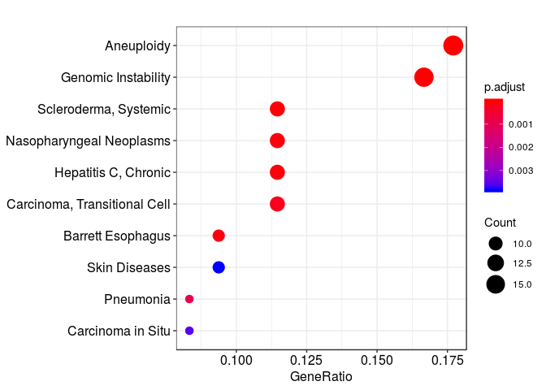

```r
dotplot(x)
```

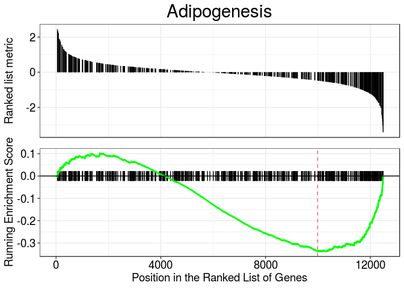

```r
gseaplot(y, y[1,1], title=y[1,2])
```

# Semantic Similarity

`meshes` implemented four IC-based methods (i.e. Resnik(Philip 1999), Jiang(Jiang and Conrath 1997), Lin(Lin 1998) and Schlicker(Schlicker et al. 2006)) and one graph-structure based method (i.e. Wang(Wang et al. 2007)). For algorithm details, please refer to the vignette of GOSemSim package(Yu et al. 2010)

`meshSim` function is designed to measure semantic similarity between two MeSH term vectors.

```r
library(meshes)
## hsamd <- meshdata("MeSH.Hsa.eg.db", category='A', computeIC=T, database="gendoo")
data(hsamd)
meshSim("D000009", "D009130", semData=hsamd, measure="Resnik")
```

```
## [1] 0.2910261
```

```r
meshSim("D000009", "D009130", semData=hsamd, measure="Rel")
```

```
## [1] 0.521396
```

```r
meshSim("D000009", "D009130", semData=hsamd, measure="Jiang")
```

```
## [1] 0.4914785
```

```r
meshSim("D000009", "D009130", semData=hsamd, measure="Wang")
```

```
## [1] 0.5557103
```

```r
meshSim(c("D001369", "D002462"), c("D017629", "D002890", "D008928"), semData=hsamd, measure="Wang")
```

```
##           D017629   D002890   D008928
## D001369 0.2886598 0.1923711 0.2193326
## D002462 0.6521739 0.2381925 0.2809552
```

`geneSim` function is designed to measure semantic similarity among two gene vectors.

```r
geneSim("241", "251", semData=hsamd, measure="Wang", combine="BMA")
```

```
## [1] 0.487
```

```r
geneSim(c("241", "251"), c("835", "5261","241", "994"), semData=hsamd, measure="Wang", combine="BMA")
```

```
##       835  5261   241   994
## 241 0.732 0.337 1.000 0.438
## 251 0.526 0.588 0.487 0.597
```

# Related tools

## Enrichment analysis

- DOSE(Yu et al. 2015)
- clusterProfiler(Yu et al. 2012)
- ReactomePA(Yu and He 2016)

## Semantic similairty measurement

- GOSemSim(Yu et al. 2010)
- DOSE(Yu et al. 2015)

# Need helps?

If you have questions/issues, please visit [meshes homepage](https://guangchuangyu.github.io/software/meshes/) first. Your problems are mostly documented. If you think you found a bug, please follow [the guide](https://guangchuangyu.github.io/2016/07/how-to-bug-author/) and provide a reproducible example to be posted on [github issue tracker](https://github.com/GuangchuangYu/meshes/issues). For questions, please post to [Bioconductor support site](https://support.bioconductor.org/) and tag your post with *meshes*.

For Chinese user, you can follow me on [WeChat (微信)](https://guangchuangyu.github.io/blog_images/biobabble.jpg).

# References

Jiang, Jay J., and David W. Conrath. 1997. “Semantic Similarity Based on Corpus Statistics and Lexical Taxonomy.” *Proceedings of 10th International Conference on Research in Computational Linguistics*. http://www.citebase.org/abstract?id=oai:arXiv.org:cmp-lg/9709008.

Lin, Dekang. 1998. “An Information-Theoretic Definition of Similarity.” *In Proceedings of the 15th International Conference on Machine Learning*, 296—304. https://doi.org/10.1.1.55.1832.

Philip, Resnik. 1999. “Semantic Similarity in a Taxonomy: An Information-Based Measure and Its Application to Problems of Ambiguity in Natural Language.” *Journal of Artificial Intelligence Research* 11:95–130.

Schlicker, Andreas, Francisco S Domingues, Jorg Rahnenfuhrer, and Thomas Lengauer. 2006. “A New Measure for Functional Similarity of Gene Products Based on Gene Ontology.” *BMC Bioinformatics* 7:302. https://doi.org/1471-2105-7-302.

Wang, James Z, Zhidian Du, Rapeeporn Payattakool, Philip S Yu, and Chin-Fu Chen. 2007. “A New Method to Measure the Semantic Similarity of Go Terms.” *Bioinformatics (Oxford, England)* 23 (May):1274–81. https://doi.org/btm087.

Yu, Guangchuang, and Qing-Yu He. 2016. “ReactomePA: An R/Bioconductor Package for Reactome Pathway Analysis and Visualization.” *Molecular BioSystems* 12 (2):477–79. https://doi.org/10.1039/C5MB00663E.

Yu, Guangchuang, Fei Li, Yide Qin, Xiaochen Bo, Yibo Wu, and Shengqi Wang. 2010. “GOSemSim: An R Package for Measuring Semantic Similarity Among Go Terms and Gene Products.” *Bioinformatics* 26 (april):976–78. https://doi.org/10.1093/bioinformatics/btq064.

Yu, Guangchuang, Li-Gen Wang, Yanyan Han, and Qing-Yu He. 2012. “clusterProfiler: an R Package for Comparing Biological Themes Among Gene Clusters.” *OMICS: A Journal of Integrative Biology* 16 (5):284–87. https://doi.org/10.1089/omi.2011.0118.

Yu, Guangchuang, Li-Gen Wang, Guang-Rong Yan, and Qing-Yu He. 2015. “DOSE: An R/Bioconductor Package for Disease Ontology Semantic and Enrichment Analysis.” *Bioinformatics* 31 (4):608–9. https://doi.org/10.1093/bioinformatics/btu684.